# Homework 4

Group D : Corti, Fabrici, Tasciotti

27/05/2020

## DAAG: Chapter 6: exercises 6,8,10,11

### Exercise 6

**The following investigates the consequences of not using a logarithmic transformation for the nihills data analysis. The second differs from the first in having a `dist x climb` interaction term, additional to linear terms in `dist` and `climb`.**

- **Fit the two models**:

```r
library(DAAG)
data(nihills)
nihills.lm <- lm(time ~ dist+climb, data=nihills)
nihills2.lm <- lm(time ~ dist+climb+dist:climb, data=nihills)
anova(nihills.lm, nihills2.lm)
```

- **Using the F-test result, make a tentative choice of model, and proceed to examine diagnostic plots. Are there any problematic observations? What happens if these points are removed? Refit both of the above models, and check the diagnostics again.**

**Solution**

In order to compare the two models, let’s run the above code:

```r
nihills.lm <- lm(time ~ dist+climb, data=nihills)
nihills2.lm <- lm(time ~ dist+climb+dist:climb, data=nihills)
anova(nihills.lm, nihills2.lm)
```

```
## Analysis of Variance Table
##
## Model 1: time ~ dist + climb
## Model 2: time ~ dist + climb + dist:climb
##   Res.Df      RSS Df Sum of Sq      F    Pr(>F)
## 1     20 0.189361
## 2     19 0.039361  1      0.15 72.406 6.623e-08 ***
## ---
## Signif. codes:  0 '***' 0.001 '**' 0.01 '*' 0.05 '.' 0.1 ' ' 1
```

The $F$ test result shows that the probability $Pr(F \geq f_{obs})$ is quite low, assuming the null hypotesis $H_0: \beta_{\text{dist x climb}}=0$ is true. Thus we can reject the null hypotesis and therefore say that `nihills2.lm`, the most complex model that includes an interaction term, appears significantly better than `nihills.lm` for `nihills` data.

For having a more precise view of the two models we proceed to examine the diagnostic plots:

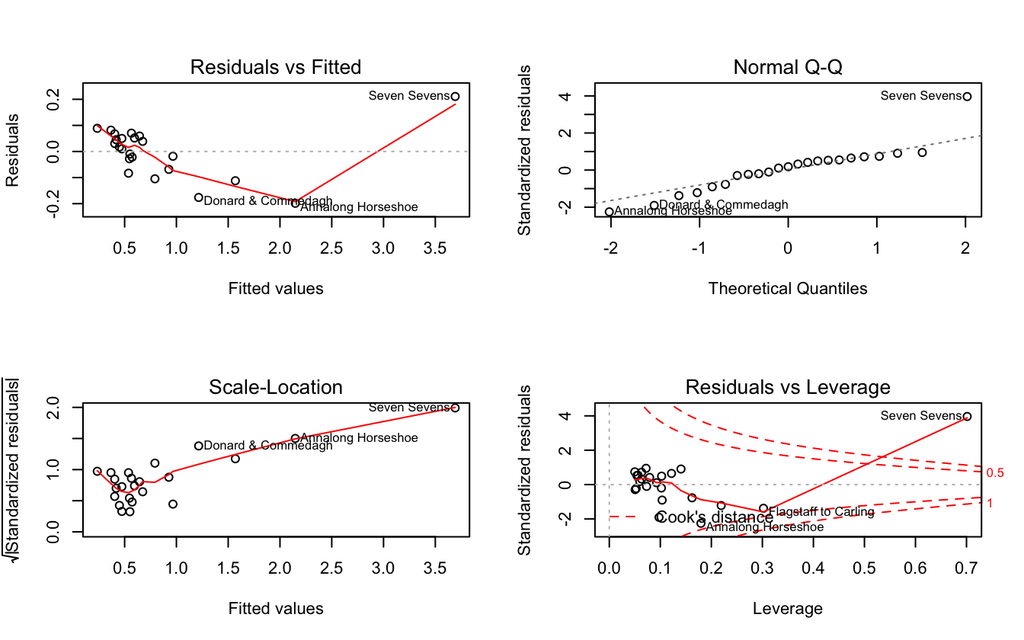

```r
## model: time = b0 + b1 dist + b2 climb
par(mfrow=c(2,2))
plot(nihills.lm)
```

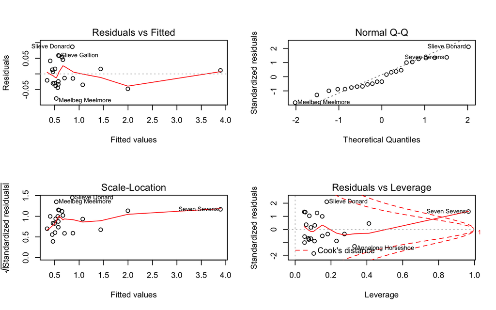

```r
## model: time = b0 + b1 dist + b2 climb + b3 (dist x climb)
par(mfrow=c(2,2))
plot(nihills2.lm)
```

Looking to these plots, at first instance, we observe that `Seven Sevens` observation looks to be a suspect point. This point has an unexpected residual and looks to have a large influence to the fit. In fact, the `Residual vs Leverage` plot shows that this point is outside the Cook’s distance lines and it also has a high standardized residual. We think then `Seven Sevens` is clearly an outlier. Moreover, from the diganostic plot of `nihills.lm`, we also suspect that the points `Annalong Horseshoe` and `Flagstaff to Carling` are problematic. Looking to the diagnostic plots of `nihill.lm2` we see that `Slieve Donard` and `Meelbeg Meelmore` also have high residuals.

Thus, we decide to remove all these suspected points:

```r
names <- list("Seven Sevens", "Annalong Horseshoe", "Slieve Donard", "Meelbeg Meelmore", "Flagstaff to Carling")
nihills <- subset(nihills, !(rownames(nihills) %in% names))
```

Without these points, we do the two fits another time and we are going to see if the null hypothesis is still rejected:

```r
# Refit models
nihills.lm <- lm(time ~ dist + climb, data = nihills)
nihills2.lm <- lm(time ~ dist + climb + dist:climb, data = nihills)
anova(nihills.lm, nihills2.lm)
```

```
## Analysis of Variance Table
##
## Model 1: time ~ dist + climb
## Model 2: time ~ dist + climb + dist:climb
##   Res.Df      RSS Df  Sum of Sq      F Pr(>F)
## 1     15 0.020572
## 2     14 0.020389  1 0.00018262 0.1254 0.7285
```

Let’s examine again the diagnostic plots:

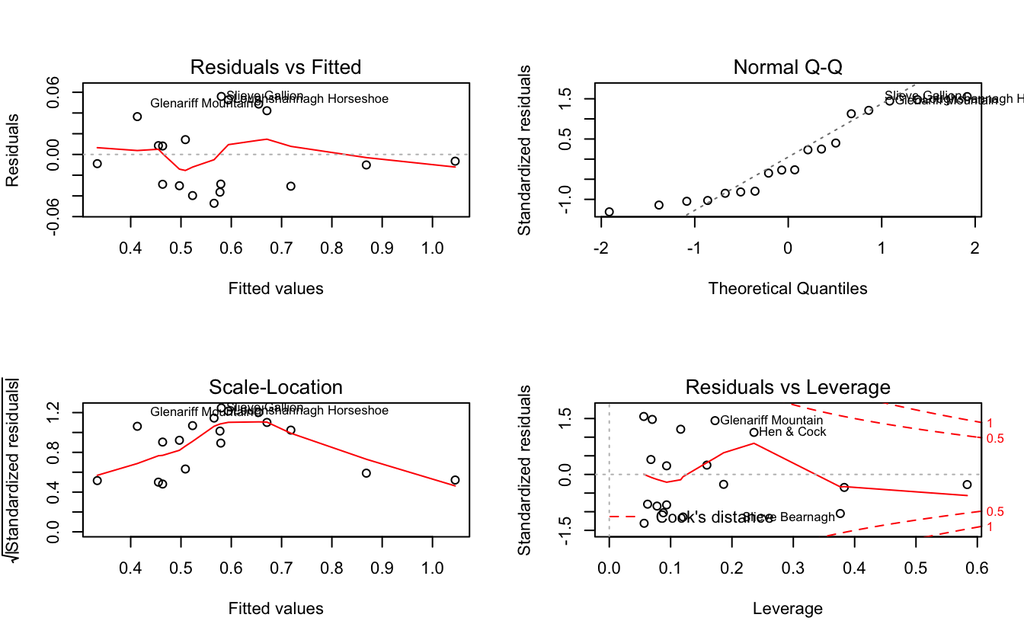

```r
## model: time = b0 + b1 dist + b2 climb
par(mfrow=c(2,2))
plot(nihills.lm)
```

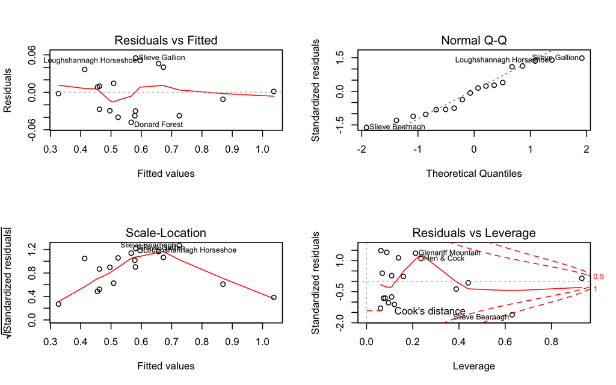

```r
## model: time = b0 + b1 dist + b2 climb + b3 (dist x climb)
par(mfrow=c(2,2))
plot(nihills2.lm)
```

Without the removed points now it looks that both models don’t have problematic points. However, `Slieve Bearnagh` is outside the Cook’s distance lines and therefore it can be an influential point.

The $F$ test on the new fitted models shows that there is no significant improvement in the more complex model over the simple one. Thus, the previous tentative choice was a mistake driven by problematic points; without them, there is no statistical reason to prefer one model to the other.

### Exercise 8

**Apply the `lm.ridge()` function to the litters data, using the generalized cross-validation (GCV) criterion to choose the tuning parameter. (GCV is an approximation to cross-validation.)**

- **In particular, estimate the coefficients of the model relating `brainwt` to `bodywt` and `lsize` and compare with the results obtained using `lm()`.**
- **Using both ridge and ordinary regression, estimate the mean brain weight when litter size is 10 and body weight is 7. Use the bootstrap, with case-resampling, to compute approximate 95% percentile confidence intervals using each method. Compare with the interval obtained using `predict.lm()`.**

**Solution**

```r
library(MASS)
data(litters)

#GCV on ridge regression
MASS::select(lm.ridge(brainwt~., data=litters, lambda = seq(0,1,0.001)))
```

```
## modified HKB estimator is 0
## modified L-W estimator is 0
## smallest value of GCV  at 0.118
```

The optimized value of the parameter $\lambda$ is $0.118$. We now use this value and we compare simple multiple linear regression with multiple ridge regression:

```r
litters_lm <- lm(brainwt~., data=litters)
litters_lm
```

```
##
## Call:
## lm(formula = brainwt ~ ., data = litters)
##
## Coefficients:
## (Intercept)        lsize       bodywt
##     0.17825      0.00669      0.02431
```

```r
litters_lm_ridge <- lm.ridge(brainwt~., data=litters, lambda = 0.118)
litters_lm_ridge
```

```
##                   lsize      bodywt
## 0.203442601 0.005661579 0.022050278
```

As expected, in the ridge regression both `bodywt` and `lsize` coefficients are penalized in favor to the intercept.

In order to obtain the $95\%$ percentile confidence intervals with bootstrap sampling we decided to build the following two functions that, given the formula model, the data, the number of bootstrap repetitions and the regularization parameter $\lambda$ (for ridge regression), would give as output the $95\%$ confidence interval for the value of `brainwt` when `lsize = 10` and `bodywt = 7`. Confidence intervals extremes are taken considering the empirical quantiles of the estimates made with boostrap sampling, assuming that each of these estimate is distributed normally with mean $\mu = \beta_0 + \beta_1 X_{\text{lsize}} + \beta_2 X_{\text{bodywt}}$, where $\beta_0, \beta_1, \beta_2$ are the population regression line coefficients.

```r
bootsrap_lm <- function(formula, data, repetitions){
  n <- nrow(data)
  s_vect <- array(0, repetitions)
  for(i in 1:repetitions) {
    ind <- sample(1:n, n, replace = TRUE)
    lm.b<-lm(formula, data=data[ind,])
    s_vect[i] <- lm.b$coefficients[1] + lm.b$coefficient[2]*10 + lm.b$coefficient[3]*7
  }
  perc_ci <- quantile(s_vect, prob=c(0.025, 0.975))
  return(perc_ci)
}

bootsrap_lm_ridge <- function(formula, data, repetitions, lambda){
  n <- nrow(data)
  s_vect <- array(0, repetitions)
  for(i in 1:repetitions) {
    ind <- sample(1:n, n, replace = TRUE)
    lm.b<-lm.ridge(formula, data=data[ind,], lambda=lambda)
    s_vect[i] <- coef(lm.b)[1] + coef(lm.b)[2]*10 + coef(lm.b)[3]*7
  }
  perc_ci <- quantile(s_vect, prob=c(0.025, 0.975))
  return(perc_ci)
}
```

```r
bootsrap_lm(formula=brainwt~., data=litters, repetitions = 10^4)
```

```
##      2.5%     97.5%
## 0.4052407 0.4231829
```

```r
bootsrap_lm_ridge(formula=brainwt~., data=litters, repetitions = 10^4, lambda = 0.118)
```

```
##      2.5%     97.5%
## 0.4046577 0.4220339
```

```r
estimate <- data.frame(lsize=10, bodywt=7)
predict.lm(lm(brainwt~., data=litters), estimate, interval = "confidence")
```

```
##         fit       lwr       upr
## 1 0.4152947 0.4062582 0.4243312
```

We can observe that our boostrap-confidence interval are quite similar for both models. Moreover, these intervals are similar also to the ones obtained with the `predict.lm` built-in function.

### Exercise 10

**The data frame `table.b3` in the `MPV` package contains data on gas mileage and 11 other variables for a sample of 32 automobiles.**

**(a) Construct a scatterplot of `y` (mpg) versus `x1` (displacement). Is the relationship between these variables non-linear?**

**(b) Use the `xyplot()` function, and `x11` (type of transmission) as a `group` variable. Is a linear model reasonable for these data?**

**(c) Fit the model relating `y` to `x1` and `x11` which gives two lines having possibly different slopes and intercepts. Check the diagnostics. Are there any influential observations? Are there any influential outliers?**

**(d) Plot the residuals against the variable `x7` (number of transmission speeds), again using `x11` as a `group` variable. Is there anything striking about this plot?**

**Solution**

**(a)**

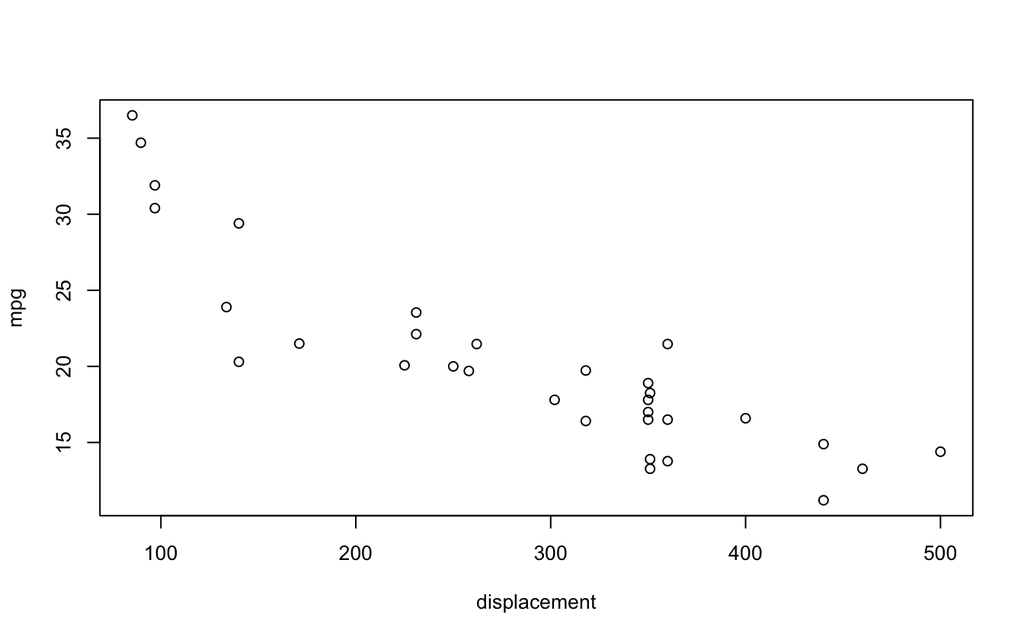

```r
library(MPV)
library(lattice)
data <- table.b3
plot(y ~ x1, xlab = "displacement", ylab = "mpg", data = data)
```

The relationship between `mpg` and `displacement` seems to be nonlinear.

**(b)**

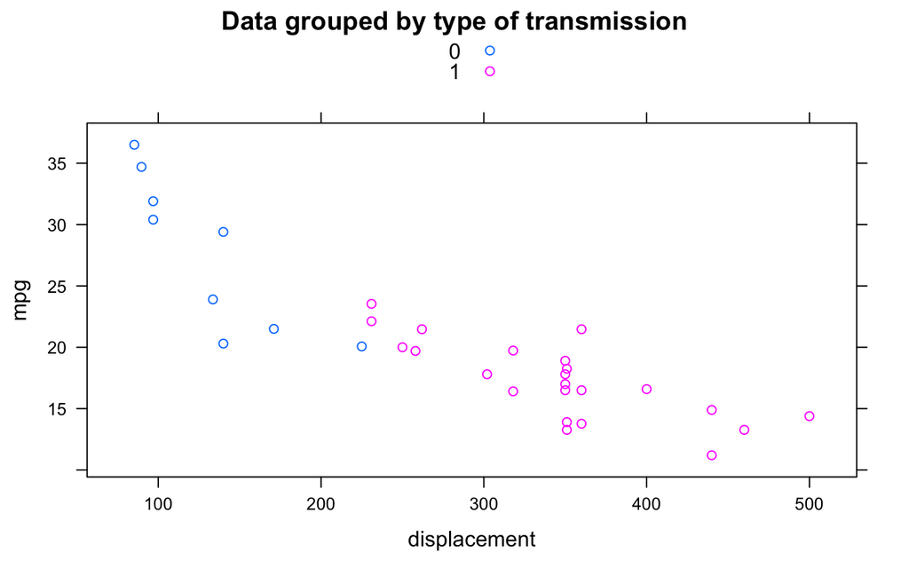

```r
xyplot(y ~ x1, group = x11, auto.key = TRUE, xlab = "displacement", ylab = "mpg", main = "Data grouped by type of transmission", data = data)
```

We can add a regression line to the previous plot in order to better visualize the relationship between the two variables.

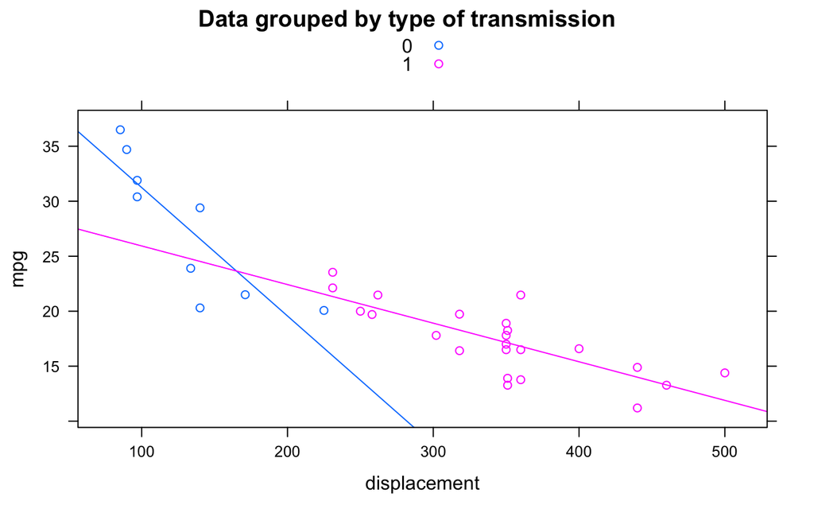

```r
xyplot(y ~ x1, group = x11, auto.key = TRUE, xlab = "displacement", ylab = "mpg", main = "Data grouped by type of transmission", data = data, type = c("p", "r"))
```

From this graph we can see that a linear model seems to be reasonable for both groups, although the values of the intercepts and slopes are different for transmission of type $0$ and for transmission of type $1$. This suggests that the nonlinearity observed from the plot in point $a$ is due to the fact that no distinction has been made between the two types of transmission.

**(c)**

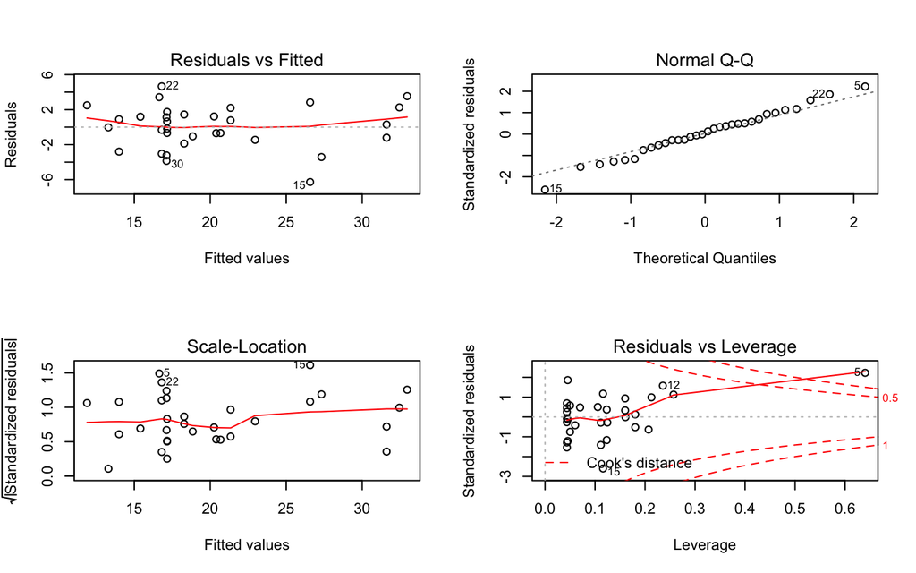

```r
model <- lm(y ~ x1 * x11, data = data)
par(mfrow=c(2,2))
plot(model)
```

The `Residuals vs Leverage` plot identifies observation $5$ as influential since it is outside of the Cook’s distance lines. However, it is not an outlier as we can see from the other diagnostic plots.

**(d)**

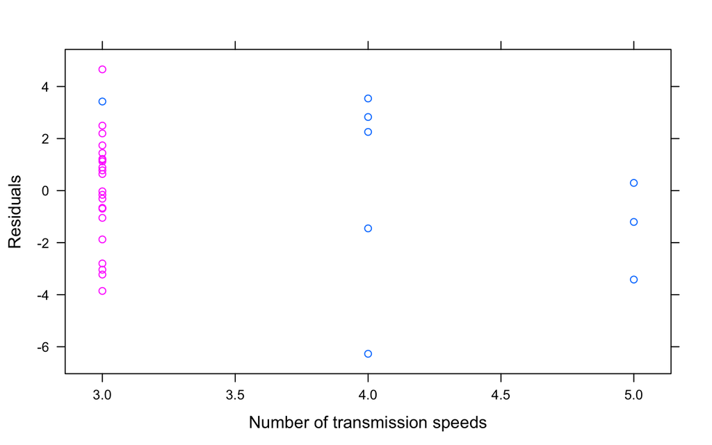

```r
xyplot(model$residuals ~ x7, group = x11, data=data, xlab = "Number of transmission speeds",ylab = "Residuals")
```

From this plot we see that the two groups (identified by the type of transmission) are almost perfectly separated; there is only one blue point among the violet ones. By inspecting the dataset, we notice that this point corresponds to observation $5$ which is indeed the only car having a 3-speed manual transmission.

### Exercise 11

**The following code is designed to explore effects that can result from the omission of explanatory variables:**

```r
library(DAAG)
set.seed(50)
x1 <- runif(10) # predictor which will be missing
x2 <- rbinom(10, 1, 1-x1) # observed predictor which depends
# on missing predictor
y <- 5*x1 + x2 + rnorm(10, sd=.1) # simulated model; coef
# of x2 is positive
y.lm <- lm(y ~ factor(x2)) # model fitted to observed data
coef(y.lm)
```

```
## (Intercept) factor(x2)1
##    3.275877   -1.031883
```

```r
 # effect of missing variable:
# coefficient of x2 has wrong sign
y.lm2 <- lm(y ~ x1 + factor(x2)) # correct model
coef(y.lm2)
```

```
## (Intercept)          x1 factor(x2)1
##  -0.1122102   5.1426235   1.0432472
```

**What happens if `x2` is generated according to `x2 <- rbinom(10, 1, x1)`? `x2 <- rbinom(10, 1, .5)`?**

**Solution**

```r
x2 <- rbinom(10, 1, x1)
y <- 5*x1 + x2 + rnorm(10,sd=.1)
y.lm <- lm(y ~ factor(x2))
coef(y.lm)
```

```
## (Intercept) factor(x2)1
##    1.063926    3.058855
```

Comparing this result obtained using `x2 <- rbinom(10, 1, x1)` with the one obtained using `x2 <- rbinom(10, 1, 1-x1)` in the model with only $x_2$ predictor, we can see that the coefficient of $x_2$ has now a positive sign. Moreover, we notice that the coefficient of $x_2$ is much larger than the expected value, that is equal to $1$. This is due to the fact that $x_2$ also reflects the information of $x_1$ since they are dependent and $x_1$ is not included in the model.

```r
y.lm2 <- lm(y ~ x1 + factor(x2))
coef(y.lm2)
```

```
## (Intercept)          x1 factor(x2)1
## -0.01962019  4.95135146  1.09934198
```

Adding the missing predictor $x_1$, we can notice that the coefficient of $x_2$ is much smaller than the one obtained before since now the variability of the response variable $y$ is highly explained by $x_1$.

```r
x2 <- rbinom(10, 1, .5)
y <- 5*x1 + x2 + rnorm(10,sd=.1)
y.lm <- lm(y ~ factor(x2))
coef(y.lm)
```

```
## (Intercept) factor(x2)1
##    1.909803    1.152584
```

Since now $x_2$ does not depend anymore on $x_1$, the coefficient of $x_2$ obtained by fitting the model $y=\beta_0 + \beta_2x_2$ is close to $1$, that is the true value of $\beta_2$.

```r
y.lm2 <- lm(y ~ x1 + factor(x2))
coef(y.lm2)
```

```
## (Intercept)          x1 factor(x2)1
## -0.08730307  4.92037521  1.08597386
```

Adding $x_1$ to the model, we see that the estimated coefficient of $x_2$ does not change significantly compared to the model in which we have only $x_2$ as predictor. This is due to the fact that now $x_2$ and $x_1$ are independent since `x2 <- rbinom(10, 1, .5)` and therefore $x_2$ does not reflect anymore the information explained by $x_1$.

## DAAG: Chapter 8: exercises 1,2,3,6.

### Exercise 1

**The following table shows numbers of occasions when inhibition (i.e., no flow of current across a membrane) occurred within 120 s, for different concentrations of the protein peptide-C (data are used with the permission of Claudia Haarmann, who obtained these data in the course of her PhD research). The outcome `yes` implies that inhibition has occurred.**

```
conc 0.1 0.5  1 10 20 30 50 70 80 100 150
no     7   1 10  9  2  9 13  1  1   4   3
yes    0   0  3  4  0  6  7  0  0   1   7
```

**Use logistic regression to model the probability of inhibition as a function of protein concentration.**

**Solution**

```r
conc <- c(0.1, 0.5, 1, 10, 20, 30, 50, 70, 80, 100, 150)
no <- c(7, 1, 10, 9, 2, 9, 13, 1, 1, 4,  3)
yes <- c(0, 0, 3, 4, 0, 6, 7, 0, 0, 1, 7)
tot <- no + yes
p <- yes / tot      # probability of inhibition
calls.glm <- glm(p ~ conc, family = binomial, weights = tot) # logit link is the default
summary(calls.glm)
```

```
##
## Call:
## glm(formula = p ~ conc, family = binomial, weights = tot)
##
## Deviance Residuals:
##     Min       1Q   Median       3Q      Max
## -1.8159  -1.0552  -0.6878   0.3667   1.0315
##
## Coefficients:
##             Estimate Std. Error z value Pr(>|z|)
## (Intercept) -1.32701    0.33837  -3.922 8.79e-05 ***
## conc         0.01215    0.00496   2.450   0.0143 *
## ---
## Signif. codes:  0 '***' 0.001 '**' 0.01 '*' 0.05 '.' 0.1 ' ' 1
##
## (Dispersion parameter for binomial family taken to be 1)
##
##     Null deviance: 16.683  on 10  degrees of freedom
## Residual deviance: 10.389  on  9  degrees of freedom
## AIC: 30.988
##
## Number of Fisher Scoring iterations: 4
```

From these results, we see that a unit increase in `conc` increases the logit with $0.01215$.

### Exercise 2

**In the data set (an artificial one of 3121 patients, that is similar to a subset of the data ana- lyzed in Stiell et al., 2001) `minor.head.injury`, obtain a logistic regression model relating `clinically.important.brain.injury` to other variables. Patients whose risk is sufficiently high will be sent for CT (computed tomography). Using a risk threshold of 0.025 (2.5%), turn the result into a decision rule for use of CT.**

**Solution**

```r
# fit the model
minor_head_injury <- head.injury
minor_head_injury <- lapply(minor_head_injury, as.factor)
model <- glm(clinically.important.brain.injury~., family = binomial, data = minor_head_injury)
summary(model)
```

```
##
## Call:
## glm(formula = clinically.important.brain.injury ~ ., family = binomial,
##     data = minor_head_injury)
##
## Deviance Residuals:
##     Min       1Q   Median       3Q      Max
## -2.2774  -0.3511  -0.2095  -0.1489   3.0028
##
## Coefficients:
##                        Estimate Std. Error z value Pr(>|z|)
## (Intercept)             -4.4972     0.1629 -27.611  < 2e-16 ***
## age.651                  1.3734     0.1827   7.518 5.56e-14 ***
## amnesia.before1          0.6893     0.1725   3.996 6.45e-05 ***
## basal.skull.fracture1    1.9620     0.2064   9.504  < 2e-16 ***
## GCS.decrease1           -0.2688     0.3680  -0.730 0.465152
## GCS.131                  1.0613     0.2820   3.764 0.000168 ***
## GCS.15.2hours1           1.9408     0.1663  11.669  < 2e-16 ***
## high.risk1               1.1115     0.1591   6.984 2.86e-12 ***
## loss.of.consciousness1   0.9554     0.1959   4.877 1.08e-06 ***
## open.skull.fracture1     0.6304     0.3151   2.001 0.045424 *
## vomiting1                1.2334     0.1961   6.290 3.17e-10 ***
## ---
## Signif. codes:  0 '***' 0.001 '**' 0.01 '*' 0.05 '.' 0.1 ' ' 1
##
## (Dispersion parameter for binomial family taken to be 1)
##
##     Null deviance: 1741.6  on 3120  degrees of freedom
## Residual deviance: 1201.3  on 3110  degrees of freedom
## AIC: 1223.3
##
## Number of Fisher Scoring iterations: 6
```

The summary function shows us that the variable `GCS.decrease` is not significance as its p-value is almost $0.5$. Thus, we remove it from our model:

```r
model <- glm(clinically.important.brain.injury~.-GCS.decrease, family = binomial, data = minor_head_injury)
summary(model)
```

```
##
## Call:
## glm(formula = clinically.important.brain.injury ~ . - GCS.decrease,
##     family = binomial, data = minor_head_injury)
##
## Deviance Residuals:
##     Min       1Q   Median       3Q      Max
## -2.3109  -0.3487  -0.2100  -0.1495   3.0000
##
## Coefficients:
##                        Estimate Std. Error z value Pr(>|z|)
## (Intercept)             -4.4889     0.1622 -27.681  < 2e-16 ***
## age.651                  1.3595     0.1818   7.478 7.52e-14 ***
## amnesia.before1          0.6852     0.1724   3.974 7.06e-05 ***
## basal.skull.fracture1    1.9305     0.2019   9.561  < 2e-16 ***
## GCS.131                  1.0585     0.2823   3.750 0.000177 ***
## GCS.15.2hours1           1.9287     0.1654  11.661  < 2e-16 ***
## high.risk1               1.1018     0.1586   6.949 3.68e-12 ***
## loss.of.consciousness1   0.9536     0.1959   4.868 1.13e-06 ***
## open.skull.fracture1     0.6174     0.3148   1.961 0.049843 *
## vomiting1                1.2250     0.1957   6.259 3.87e-10 ***
## ---
## Signif. codes:  0 '***' 0.001 '**' 0.01 '*' 0.05 '.' 0.1 ' ' 1
##
## (Dispersion parameter for binomial family taken to be 1)
##
##     Null deviance: 1741.6  on 3120  degrees of freedom
## Residual deviance: 1201.9  on 3111  degrees of freedom
## AIC: 1221.9
##
## Number of Fisher Scoring iterations: 6
```

In order to obtain a decision rule for use of CT using a risk threshold of $p=0.025$, we have to identify all patients which have a risk greater or equal than $p$. Considering the logit of p, this is equivalent to state that $log\bigg(\frac{p}{1-p}\bigg)=-3.66 \leq \beta_0 + \beta_1x_1+...+\beta_{10}x_{10}$, where $x_i \in \{0,1\}$ (with i=1,…,10). Since the estimated intercept is equal to $-4.4889$, patients will be sent for CT if they have a combination of clinical conditions that returns a value greater or equal to $-3.66+4.4889=0.8289$.  
This risk results from:

1. any of the predictors `age.65`, `basal.skull.fracture`, `GCS.13`, `GCS.15.2hours`, `high.risk`, `loss.of.consciousness` and `vomiting`, regardless of the presence or absence of other clinical conditions;
2. `amnesia.before` or `open.skull.fracture` with any of the other predictors.

Thus, a patient should be sent for CT if conditions $1.$ or $2.$ are met.

### Exercise 3

**Consider again the moths data set of Section 8.4.**

- **What happens to the standard error estimates when the poisson family is used in glm() instead of the quasipoisson family?**
- **Analyze the `P` moths, in the same way as the `A` moths were analyzed. Comment on the effect of transect length.**

**Solution**

```r
data("moths")
moths$habitat <- relevel(moths$habitat, ref="Lowerside")
summary(A.glm <- glm(A ~ habitat + log(meters), family=quasipoisson, data=moths))
```

```
##
## Call:
## glm(formula = A ~ habitat + log(meters), family = quasipoisson,
##     data = moths)
##
## Deviance Residuals:
##     Min       1Q   Median       3Q      Max
## -3.5562  -1.4635  -0.0007   0.9248   3.0822
##
## Coefficients:
##                    Estimate Std. Error t value Pr(>|t|)
## (Intercept)         1.20981    0.45530   2.657   0.0122 *
## habitatBank       -16.90566 2096.58841  -0.008   0.9936
## habitatDisturbed   -1.28323    0.64737  -1.982   0.0561 .
## habitatNEsoak      -0.82170    0.53700  -1.530   0.1358
## habitatNWsoak       1.56243    0.33426   4.674 5.11e-05 ***
## habitatSEsoak       0.06206    0.38515   0.161   0.8730
## habitatSWsoak       0.23143    0.47807   0.484   0.6316
## habitatUpperside   -0.16234    0.58429  -0.278   0.7829
## log(meters)         0.12917    0.15278   0.845   0.4041
## ---
## Signif. codes:  0 '***' 0.001 '**' 0.01 '*' 0.05 '.' 0.1 ' ' 1
##
## (Dispersion parameter for quasipoisson family taken to be 2.700801)
##
##     Null deviance: 257.108  on 40  degrees of freedom
## Residual deviance:  93.991  on 32  degrees of freedom
## AIC: NA
##
## Number of Fisher Scoring iterations: 13
```

```r
summary(A.glm <- glm(A ~ habitat + log(meters), family=poisson, data=moths))
```

```
##
## Call:
## glm(formula = A ~ habitat + log(meters), family = poisson, data = moths)
##
## Deviance Residuals:
##     Min       1Q   Median       3Q      Max
## -3.5562  -1.4635  -0.0007   0.9248   3.0822
##
## Coefficients:
##                    Estimate Std. Error z value Pr(>|z|)
## (Intercept)         1.20981    0.27705   4.367 1.26e-05 ***
## habitatBank       -16.90566 1275.75387  -0.013  0.98943
## habitatDisturbed   -1.28323    0.39392  -3.258  0.00112 **
## habitatNEsoak      -0.82170    0.32676  -2.515  0.01191 *
## habitatNWsoak       1.56243    0.20340   7.682 1.57e-14 ***
## habitatSEsoak       0.06206    0.23436   0.265  0.79114
## habitatSWsoak       0.23143    0.29090   0.796  0.42628
## habitatUpperside   -0.16234    0.35554  -0.457  0.64796
## log(meters)         0.12917    0.09297   1.389  0.16471
## ---
## Signif. codes:  0 '***' 0.001 '**' 0.01 '*' 0.05 '.' 0.1 ' ' 1
##
## (Dispersion parameter for poisson family taken to be 1)
##
##     Null deviance: 257.108  on 40  degrees of freedom
## Residual deviance:  93.991  on 32  degrees of freedom
## AIC: 226.71
##
## Number of Fisher Scoring iterations: 13
```

```r
sapply(split(moths$P, moths$habitat), sum)
```

```
## Lowerside      Bank Disturbed    NEsoak    NWsoak    SEsoak    SWsoak
##        17         4        33        14        19         6        48
## Upperside
##         8
```

```r
moths$habitat <- relevel(moths$habitat, ref="Lowerside")

summary(P.glm <- glm(P ~ habitat + log(meters), family=quasipoisson, data=moths))
```

```
##
## Call:
## glm(formula = P ~ habitat + log(meters), family = quasipoisson,
##     data = moths)
##
## Deviance Residuals:
##     Min       1Q   Median       3Q      Max
## -2.9479  -1.3155  -0.4167   0.5660   2.9719
##
## Coefficients:
##                  Estimate Std. Error t value Pr(>|t|)
## (Intercept)       -0.8608     0.6745  -1.276  0.21105
## habitatBank        0.5569     0.8837   0.630  0.53301
## habitatDisturbed   1.4364     0.5172   2.777  0.00909 **
## habitatNEsoak     -0.3211     0.5844  -0.549  0.58651
## habitatNWsoak      1.0106     0.5309   1.904  0.06598 .
## habitatSEsoak     -1.0697     0.7560  -1.415  0.16673
## habitatSWsoak      1.6383     0.4582   3.575  0.00113 **
## habitatUpperside  -1.5773     0.7757  -2.033  0.05038 .
## log(meters)        0.5552     0.1759   3.157  0.00347 **
## ---
## Signif. codes:  0 '***' 0.001 '**' 0.01 '*' 0.05 '.' 0.1 ' ' 1
##
## (Dispersion parameter for quasipoisson family taken to be 2.527554)
##
##     Null deviance: 217.819  on 40  degrees of freedom
## Residual deviance:  76.924  on 32  degrees of freedom
## AIC: NA
##
## Number of Fisher Scoring iterations: 6
```

### Exercise 6

**As in the previous exercise, the function `poissonsim()` allows for experimentation with Poisson regression. In particular, `poissonsim()` can be used to simulate Poisson responses with log-rates equal to $a + bx$, where $a$ and $b$ are fixed values by default.**

(a) Simulate $100$ Poisson responses using the model
$$log\lambda = 2 − 4x$$
for $x = 0, 0.01, 0.02,..., 1.0$. Fit a Poisson regression model to these data, and compare the estimated coefficients with the true coefficients. How well does the estimated model predict future observations?

(b) Simulate $100$ Poisson responses using the model
$$log\lambda = 2 − bx$$
where $b$ is normally distributed with mean $4$ and standard deviation $5$. [Use the argument `slope.sd`$=5$ in the `poissonsim()` function.] How do the results using the `poisson` and `quasipoisson` families differ?

**Solution**

**(a)**

```r
library(DAAG)
library(MASS) # for function confint()
x <- seq(0, 1, length=101)
# simulate 100 Poisson responses
simulated <- poissonsim(x , a = 2, b = -4)
# fit poisson regression model to these data
model <- glm(y ~ x, family = poisson, data = simulated)
# estimated coefficients
estimated_coeff <- summary(model)$coeff
estimated_coeff
```

```
##              Estimate Std. Error   z value     Pr(>|z|)
## (Intercept)  1.783069  0.1182839  15.07449 2.383572e-51
## x           -3.748605  0.3672274 -10.20786 1.828575e-24
```

```r
# compute approximate 95% normal confidence intervals for parameter a and b
confint(model)
```

```
##                 2.5 %    97.5 %
## (Intercept)  1.545552  2.009524
## x           -4.492230 -3.050506
```

From these results we can see that the estimated coefficients `a` and `b` are included into the approximate $95\%$ normal confidence intervals computed with the function `confint`.  
Regarding to the goodness of the predictions obtained with the estimated model, we can observe that, when $x$ tends to infinity (which corresponds to future predictions) and when the estimated coefficients are such that $\hat a>0$ and $\hat b <0$, the rate $\lambda$ of the Poisson distribution tends to $0$, since $\lambda=e^{\hat a+ \hat b x}$, and also its variance. For this reason, regardless of the values of the estimated coefficients, the future predicitons will be really close to the true values since the variance $var(\lambda)$ tends to $0$ as $x$ tends to $+\infty$.

**(b)**

```r
x <- seq(0, 0.99, 0.01)
simulated <-  poissonsim(x, a = 2, b = -4, slope.sd = 5)
model <- glm(y ~ x, family = poisson, data = simulated)
model2 <- glm(y ~ x, family = quasipoisson, data = simulated)
summary(model)
```

```
##
## Call:
## glm(formula = y ~ x, family = poisson, data = simulated)
##
## Deviance Residuals:
##     Min       1Q   Median       3Q      Max
## -14.791  -11.805   -9.102   -5.972  175.648
##
## Coefficients:
##             Estimate Std. Error z value Pr(>|z|)
## (Intercept)  3.26059    0.03197  102.00   <2e-16 ***
## x            1.46361    0.04762   30.74   <2e-16 ***
## ---
## Signif. codes:  0 '***' 0.001 '**' 0.01 '*' 0.05 '.' 0.1 ' ' 1
##
## (Dispersion parameter for poisson family taken to be 1)
##
##     Null deviance: 42407  on 99  degrees of freedom
## Residual deviance: 41412  on 98  degrees of freedom
## AIC: 41655
##
## Number of Fisher Scoring iterations: 11
```

```r
summary(model2)
```

```
##
## Call:
## glm(formula = y ~ x, family = quasipoisson, data = simulated)
##
## Deviance Residuals:
##     Min       1Q   Median       3Q      Max
## -14.791  -11.805   -9.102   -5.972  175.648
##
## Coefficients:
##             Estimate Std. Error t value Pr(>|t|)
## (Intercept)    3.261      1.864   1.749   0.0834 .
## x              1.464      2.777   0.527   0.5994
## ---
## Signif. codes:  0 '***' 0.001 '**' 0.01 '*' 0.05 '.' 0.1 ' ' 1
##
## (Dispersion parameter for quasipoisson family taken to be 3401.222)
##
##     Null deviance: 42407  on 99  degrees of freedom
## Residual deviance: 41412  on 98  degrees of freedom
## AIC: NA
##
## Number of Fisher Scoring iterations: 11
```

From the `summary` output we can see that, as expected, the estimated coefficients are the same for both models. However, in the quasiPoisson model the dispersion parameter is much larger than that of the Poisson model. Thus, we have different standard errors and p-values. Indeed, in the Poisson model both `intercept` and `x` are highly significant, while this is no longer true in the quasiPoisson model.